# Heart disease Analysis project

Sengdao_Oudomsihn

4/15/2022

Age = age in year Sex = gender of patients; 1=male, 0=female CP_Type = chest pain type (Typical angina, Atypical angina, Non-anginal pain, Asymptomatic) BloodPres = blood pressure (millimeters of mercury (mmHg)) Cholesterol = serum cholesterol in mg/dl Fasting_BP = fasting blood sugar >120 mg/dl (1=true; 0=false) Rest_ECG = resting electrocardiographic results (0=normal, 1= can range from mild symptoms to severe problems, 2: possible or definite left ventricular hypertrophy MaxHR = maximum heart rate achieved Exercise = Exercise induced angina (1= yes, 0=no) ST_Dep = ST Depression induced by exercise relative to rest Slope_ST =The slope of the peak exercise ST segment (1:upsloping, 2: flat sloping and 3: downsloping Num_Vsel = number of major vessels (0-3) Thallium_Stress = Thallium stress result (3: normal, 6: fixed defect, 7: reversible defect HD = Heart disease conditions

this statistical analysis aims not to classify the type of heart condition, but on the other hand, the aim of the paper is to investigate whether; 1. Age has no effect on the heart disease condition of patients 2. ST-Segment Depression has no effects the ST-elevation of heart rate 3. Age and sex are not predictors for heart disease 4. ST-segment Depression (ST_Dep) and ST-elevation of heart rate are predictors for different kinds of chest pains 5. There is no correlation between age and cholesterol 6. There is no correlation between blood pressure and cholesterol 7. There is no correlation between age and maximum heart rate

A few types of statistical analysis models will be used to find the answer for hypotheses. These types of statistical analysis models include one-way ANOVA, two-way ANOVA, and linear regression. Each statistical analysis model is unique in its own way, and each is used differently based on the type of data that are being compared. So the hypotheses for this analysis include many types of data. Therefore I will use different statistical analysis models for each hypothesis testing.

# tidyverse package

```r
# install.packages("tidyverse")
library(tidyverse)
```

# referenece source of dataset: https://archive.ics.uci.edu/ml/datasets/Heart+Disease

```r
urlfile="https://archive.ics.uci.edu/ml/machine-learning-databases/heart-disease/processed.cleveland.data"
my_data <- read.csv(urlfile)
str(my_data)
```

```
## 'data.frame':    302 obs. of  14 variables:
##  $ X63.0 : num  67 67 37 41 56 62 57 63 53 57 ...
##  $ X1.0  : num  1 1 1 0 1 0 0 1 1 1 ...
##  $ X1.0.1: num  4 4 3 2 2 4 4 4 4 4 ...
##  $ X145.0: num  160 120 130 130 120 140 120 130 140 140 ...
##  $ X233.0: num  286 229 250 204 236 268 354 254 203 192 ...
##  $ X1.0.2: num  0 0 0 0 0 0 0 0 1 0 ...
##  $ X2.0  : num  2 2 0 2 0 2 0 2 2 0 ...
##  $ X150.0: num  108 129 187 172 178 160 163 147 155 148 ...
##  $ X0.0  : num  1 1 0 0 0 0 1 0 1 0 ...
##  $ X2.3  : num  1.5 2.6 3.5 1.4 0.8 3.6 0.6 1.4 3.1 0.4 ...
##  $ X3.0  : num  2 2 3 1 1 3 1 2 3 2 ...
##  $ X0.0.1: chr  "3.0" "2.0" "0.0" "0.0" ...
##  $ X6.0  : chr  "3.0" "7.0" "3.0" "3.0" ...
##  $ X0    : int  2 1 0 0 0 3 0 2 1 0 ...
```

# Assign names to the column names

```r
colnames(my_data) <- c("Age","Sex","CP_Type", "BloodPres", "Cholesterol", "Fasting_BP",  "Rest_ECG", "MaxHR", "Exercise",  "ST_Dep", "Slope_ST", "Num_Vsels", "Thallium_Stress", "HD")
str(my_data)
```

```
## 'data.frame':    302 obs. of  14 variables:
##  $ Age            : num  67 67 37 41 56 62 57 63 53 57 ...
##  $ Sex            : num  1 1 1 0 1 0 0 1 1 1 ...
##  $ CP_Type        : num  4 4 3 2 2 4 4 4 4 4 ...
##  $ BloodPres      : num  160 120 130 130 120 140 120 130 140 140 ...
##  $ Cholesterol    : num  286 229 250 204 236 268 354 254 203 192 ...
##  $ Fasting_BP     : num  0 0 0 0 0 0 0 0 1 0 ...
##  $ Rest_ECG       : num  2 2 0 2 0 2 0 2 2 0 ...
##  $ MaxHR          : num  108 129 187 172 178 160 163 147 155 148 ...
##  $ Exercise       : num  1 1 0 0 0 0 1 0 1 0 ...
##  $ ST_Dep         : num  1.5 2.6 3.5 1.4 0.8 3.6 0.6 1.4 3.1 0.4 ...
##  $ Slope_ST       : num  2 2 3 1 1 3 1 2 3 2 ...
##  $ Num_Vsels      : chr  "3.0" "2.0" "0.0" "0.0" ...
##  $ Thallium_Stress: chr  "3.0" "7.0" "3.0" "3.0" ...
##  $ HD             : int  2 1 0 0 0 3 0 2 1 0 ...
```

# Checking if there are any missing values in the dataset

```r
## Data cleaning
any(is.na(my_data)) # check if there is any missing value in the dataset. TRUE mean yes there are missing value in the data frame
```

```
## [1] FALSE
```

```r
my_data[my_data == "?"] <- NA # Replace "?" in any column with NA
colSums(is.na(my_data))# which column has missing value
```

```
##             Age             Sex         CP_Type       BloodPres     Cholesterol
##               0               0               0               0               0
##      Fasting_BP        Rest_ECG           MaxHR        Exercise          ST_Dep
##               0               0               0               0               0
##        Slope_ST       Num_Vsels Thallium_Stress              HD
##               0               4               2               0
```

# delete anny missing value that could potentially cause problem for analysis

```r
my_data <- na.omit(my_data) # omit the missing value in the dataset and save it back to the dateset
any(is.na(my_data)) # False means no missing value in the dataset
```

```
## [1] FALSE
```

```r
my_data[my_data$CP_Type == 1,]$CP_Type <- "Typical angina"
my_data[my_data$CP_Type == 2,]$CP_Type <- "Atypical angina"
my_data[my_data$CP_Type == 3,]$CP_Type <- "Non-anginal pain"
my_data[my_data$CP_Type == 4,]$CP_Type <- "Asymptomatic"
my_data[my_data$Exercise  == 0,]$Exercise  <- "No_Exercise"
my_data[my_data$Exercise  == 1,]$Exercise  <- "Yes_Exercise"
my_data[my_data$Slope_ST == 1,]$Slope_ST <- "Upsloping"
my_data[my_data$Slope_ST == 2,]$Slope_ST <- "Flatsloping"
my_data[my_data$Slope_ST == 3,]$Slope_ST <- "Downsloping"
my_data[my_data$Sex == 1,]$Sex <- "Male"
my_data[my_data$Sex == 0,]$Sex <- "Female"
my_data[my_data$HD == 0,]$HD <- "Healthy"
my_data[my_data$HD == 1,]$HD <- "Unhealthy"
my_data[my_data$HD == 2,]$HD <- "Unhealthy"
my_data[my_data$HD == 3,]$HD <- "Unhealthy"
my_data[my_data$HD == 4,]$HD <- "Unhealthy"
str(my_data)
```

```
## 'data.frame':    296 obs. of  14 variables:
##  $ Age            : num  67 67 37 41 56 62 57 63 53 57 ...
##  $ Sex            : chr  "Male" "Male" "Male" "Female" ...
##  $ CP_Type        : chr  "Asymptomatic" "Asymptomatic" "Non-anginal pain" "Atypical angina" ...
##  $ BloodPres      : num  160 120 130 130 120 140 120 130 140 140 ...
##  $ Cholesterol    : num  286 229 250 204 236 268 354 254 203 192 ...
##  $ Fasting_BP     : num  0 0 0 0 0 0 0 0 1 0 ...
##  $ Rest_ECG       : num  2 2 0 2 0 2 0 2 2 0 ...
##  $ MaxHR          : num  108 129 187 172 178 160 163 147 155 148 ...
##  $ Exercise       : chr  "Yes_Exercise" "Yes_Exercise" "No_Exercise" "No_Exercise" ...
##  $ ST_Dep         : num  1.5 2.6 3.5 1.4 0.8 3.6 0.6 1.4 3.1 0.4 ...
##  $ Slope_ST       : chr  "Flatsloping" "Flatsloping" "Downsloping" "Upsloping" ...
##  $ Num_Vsels      : chr  "3.0" "2.0" "0.0" "0.0" ...
##  $ Thallium_Stress: chr  "3.0" "7.0" "3.0" "3.0" ...
##  $ HD             : chr  "Unhealthy" "Unhealthy" "Healthy" "Healthy" ...
##  - attr(*, "na.action")= 'omit' Named int [1:6] 87 166 192 266 287 302
##   ..- attr(*, "names")= chr [1:6] "87" "166" "192" "266" ...
```

# convert some variables in the dataset into appropiate data type for analysis

```r
# Now let's convert some variables into factor
my_data$Age <- as.integer(my_data$Age)
my_data$Sex <- as.factor(my_data$Sex)
my_data$CP_Type <- as.factor(my_data$CP_Type)
my_data$Fasting_BP <- as.factor(my_data$Fasting_BP)
my_data$Rest_ECG <- as.factor(my_data$Rest_ECG)
my_data$Exercise <- as.factor(my_data$Exercise)
my_data$Slope_ST <- as.factor(my_data$Slope_ST)
my_data$Num_Vsels <- as.factor(my_data$Num_Vsels)
my_data$Thallium_Stress <- as.factor(my_data$Thallium_Stress)
my_data$BloodPres <- as.numeric(my_data$BloodPres)
my_data$Cholesterol <- as.numeric(my_data$Cholesterol)
my_data$MaxHR <- as.numeric(my_data$MaxHR)
my_data$HD <- as.factor(my_data$HD)
str(my_data)
```

```
## 'data.frame':    296 obs. of  14 variables:
##  $ Age            : int  67 67 37 41 56 62 57 63 53 57 ...
##  $ Sex            : Factor w/ 2 levels "Female","Male": 2 2 2 1 2 1 1 2 2 2 ...
##  $ CP_Type        : Factor w/ 4 levels "Asymptomatic",..: 1 1 3 2 2 1 1 1 1 1 ...
##  $ BloodPres      : num  160 120 130 130 120 140 120 130 140 140 ...
##  $ Cholesterol    : num  286 229 250 204 236 268 354 254 203 192 ...
##  $ Fasting_BP     : Factor w/ 2 levels "0","1": 1 1 1 1 1 1 1 1 2 1 ...
##  $ Rest_ECG       : Factor w/ 3 levels "0","1","2": 3 3 1 3 1 3 1 3 3 1 ...
##  $ MaxHR          : num  108 129 187 172 178 160 163 147 155 148 ...
##  $ Exercise       : Factor w/ 2 levels "No_Exercise",..: 2 2 1 1 1 1 2 1 2 1 ...
##  $ ST_Dep         : num  1.5 2.6 3.5 1.4 0.8 3.6 0.6 1.4 3.1 0.4 ...
##  $ Slope_ST       : Factor w/ 3 levels "Downsloping",..: 2 2 1 3 3 1 3 2 1 2 ...
##  $ Num_Vsels      : Factor w/ 4 levels "0.0","1.0","2.0",..: 4 3 1 1 1 3 1 2 1 1 ...
##  $ Thallium_Stress: Factor w/ 3 levels "3.0","6.0","7.0": 1 3 1 1 1 1 1 3 3 2 ...
##  $ HD             : Factor w/ 2 levels "Healthy","Unhealthy": 2 2 1 1 1 2 1 2 2 1 ...
##  - attr(*, "na.action")= 'omit' Named int [1:6] 87 166 192 266 287 302
##   ..- attr(*, "names")= chr [1:6] "87" "166" "192" "266" ...
```

# Exploratory Data Analysis

### Histogram to see distribution of data in the dataset

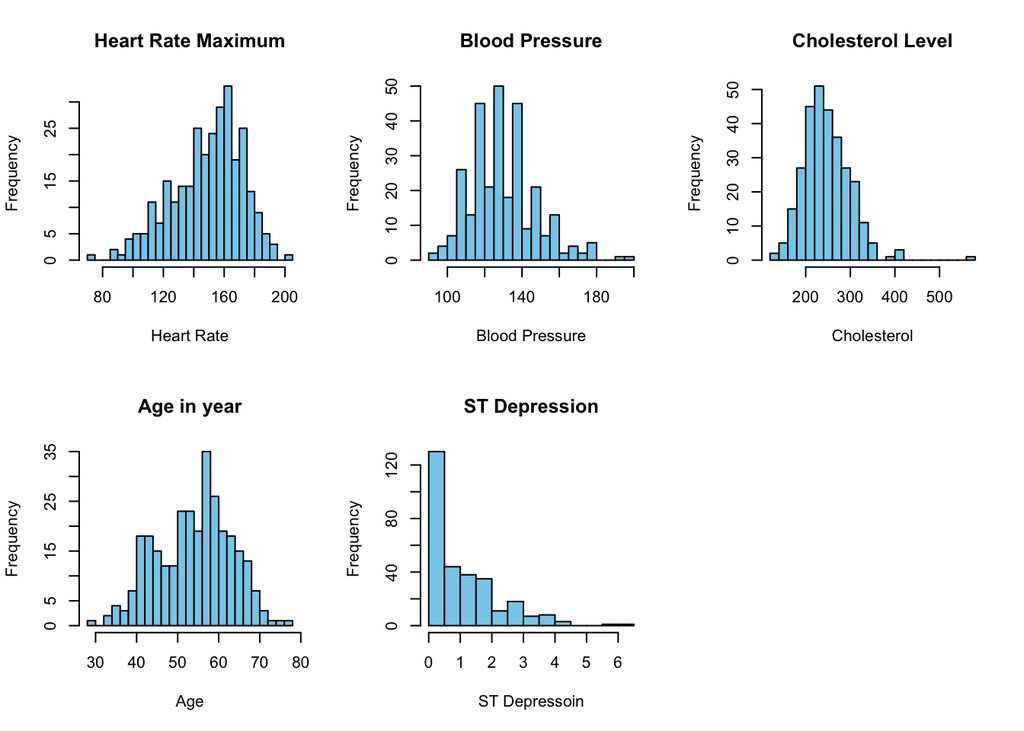

```r
set.seed(123)
par(mfrow=c(2,3))
hist(my_data$MaxHR, breaks = 20, col="skyblue", main="Heart Rate Maximum", xlab = "Heart Rate")
hist(my_data$BloodPres,breaks = 20, col="skyblue", main="Blood Pressure", xlab = "Blood Pressure")
hist(my_data$Cholesterol, breaks = 20,col="skyblue", main = "Cholesterol Level", xlab = "Cholesterol")
hist(my_data$Age, breaks = 20, col="skyblue", main = "Age in year", xlab = "Age")
hist(my_data$ST_Dep, breaks = 20, col="skyblue", main = "ST Depression", xlab = "ST Depressoin")
```

#### Figure1: Histogram of distribution of data for maximum heart rate, blood pressure, cholesterol level, age, and ST depression for patients in the dataset.

# density of data distribution in chest pain

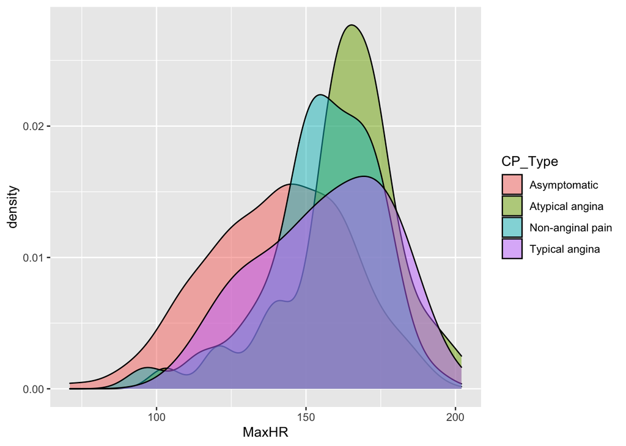

```r
ggplot(my_data,aes(x=MaxHR, fill=CP_Type))+geom_density(alpha=.5)
```

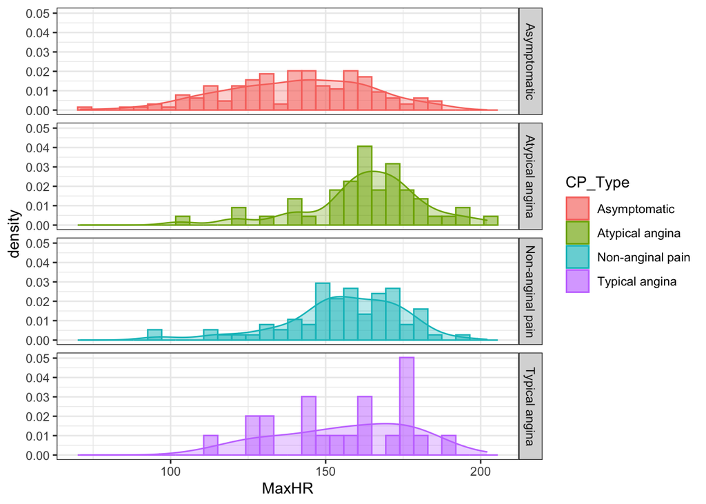

```r
ggplot(data = my_data, aes(x=MaxHR, color=CP_Type, fill= CP_Type))+
  geom_histogram(aes(y=..density..), alpha=0.5,
                 position = "identity")+
  geom_density(alpha=.3)+
  facet_grid(CP_Type~.)+
  theme_bw()
```

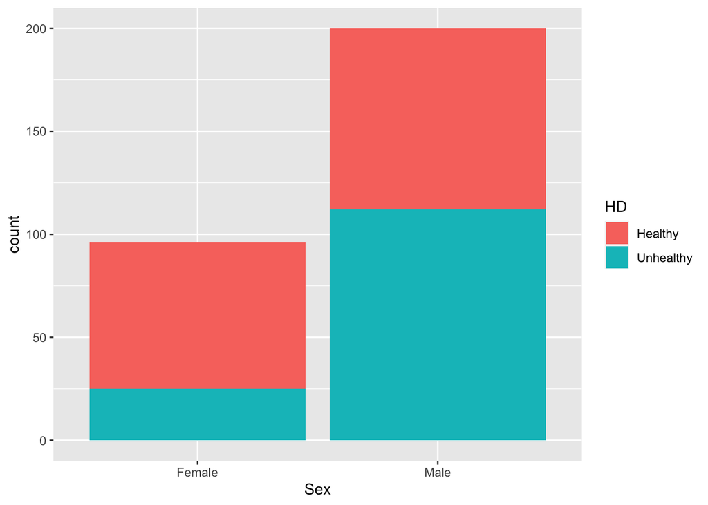

```r
ggplot(data=my_data)+geom_bar(mapping = aes(x=Sex, fill=HD))
```

```r
my_data %>% group_by(CP_Type) %>%
  count() %>%
  arrange(desc(n))
```

```
## # A tibble: 4 × 2
## # Groups:   CP_Type [4]
##   CP_Type              n
##   <fct>            <int>
## 1 Asymptomatic       142
## 2 Non-anginal pain    83
## 3 Atypical angina     49
## 4 Typical angina      22
```

```r
my_data %>%
  filter(CP_Type=="Asymptomatic") %>%
  group_by(HD, Sex, CP_Type) %>%
  summarise(avg_HR=mean(MaxHR),
            median_HR=median(MaxHR),
            avg_age=mean(Age),
            median_age=median(Age)
            )
```

```
## # A tibble: 4 × 7
## # Groups:   HD, Sex [4]
##   HD        Sex    CP_Type      avg_HR median_HR avg_age median_age
##   <fct>     <fct>  <fct>         <dbl>     <dbl>   <dbl>      <dbl>
## 1 Healthy   Female Asymptomatic   148.      153     55.2       57
## 2 Healthy   Male   Asymptomatic   156       160     53.1       53
## 3 Unhealthy Female Asymptomatic   143.      146.    59.1       60.5
## 4 Unhealthy Male   Asymptomatic   134.      132     55.8       57
```

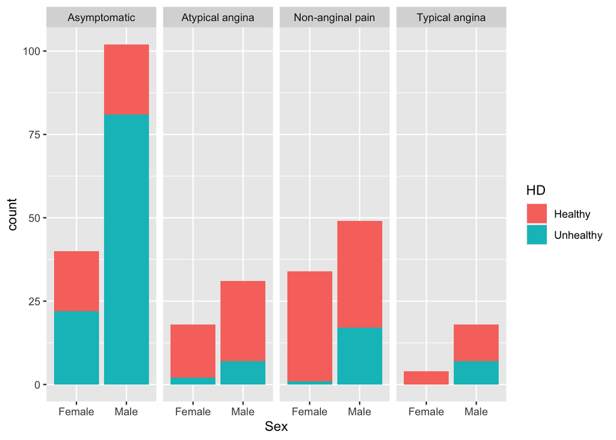

```r
ggplot(data=my_data)+geom_bar(mapping = aes(x=Sex, fill=HD))+facet_grid(~CP_Type)
```

```r
my_data %>%
  filter(CP_Type=="Asymptomatic") %>%
  group_by(HD, Sex, CP_Type) %>%
  summarise_if(is.numeric, median)
```

```
## # A tibble: 4 × 8
## # Groups:   HD, Sex [4]
##   HD        Sex    CP_Type        Age BloodPres Cholesterol MaxHR ST_Dep
##   <fct>     <fct>  <fct>        <dbl>     <dbl>       <dbl> <dbl>  <dbl>
## 1 Healthy   Female Asymptomatic  57        130         251   153    0.35
## 2 Healthy   Male   Asymptomatic  53        128         228   160    0.2
## 3 Unhealthy Female Asymptomatic  60.5      148.        268.  146.   1.85
## 4 Unhealthy Male   Asymptomatic  57        128         249   132    1.4
```

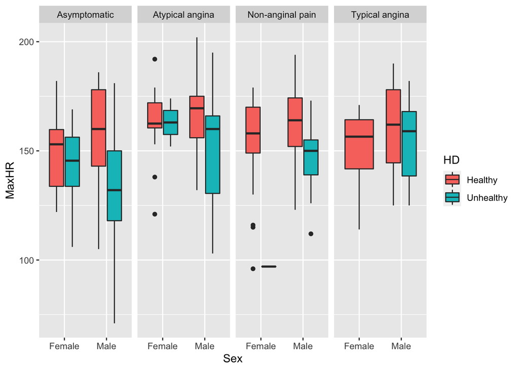

```r
ggplot(data = my_data, aes(x= Sex, y= MaxHR, fill= HD))+geom_boxplot()+
  facet_grid(.~CP_Type)
```

# Statistical Analysis | Finding insight in data

## ONE-Way ANOVA

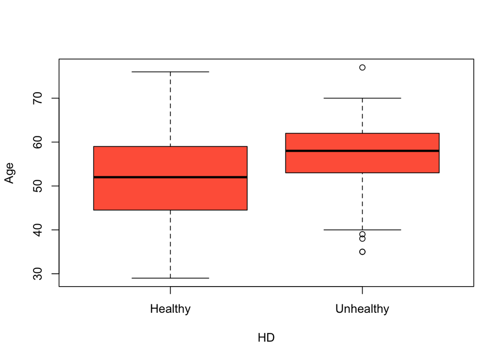

```r
# One-Way ANOVA
boxplot(Age~HD, data=my_data, col='tomato')
```

```r
ONE_ANOVA1 <- aov(Age~HD, data=my_data)
summary(ONE_ANOVA1)
```

```
##              Df Sum Sq Mean Sq F value   Pr(>F)
## HD            1   1286  1286.1   16.52 6.17e-05 ***
## Residuals   294  22884    77.8
## ---
## Signif. codes:  0 '***' 0.001 '**' 0.01 '*' 0.05 '.' 0.1 ' ' 1
```

```r
TukeyHSD(ONE_ANOVA1)
```

```
##   Tukey multiple comparisons of means
##     95% family-wise confidence level
##
## Fit: aov(formula = Age ~ HD, data = my_data)
##
## $HD
##                       diff      lwr      upr    p adj
## Unhealthy-Healthy 4.180508 2.156477 6.204539 6.17e-05
```

## Older age patients have higer unhealthy heart condition than younger age patients

Report: “Age of patients are significantly different for heart disease condition(One-way anova, F_1,294=16,52, p<0.0000617)”

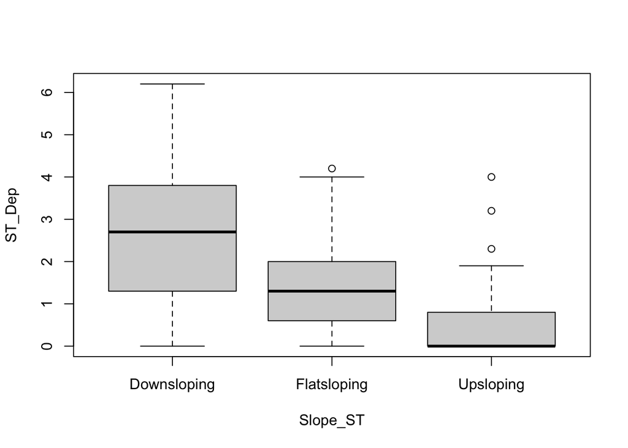

```r
set.seed(11)
boxplot(ST_Dep~Slope_ST, data=my_data)
```

```r
ONE_ANOVA2 <- aov(ST_Dep~Slope_ST, data = my_data)
ONE_ANOVA2
```

```
## Call:
##    aov(formula = ST_Dep ~ Slope_ST, data = my_data)
##
## Terms:
##                 Slope_ST Residuals
## Sum of Squares  134.2331  266.7264
## Deg. of Freedom        2       293
##
## Residual standard error: 0.9541116
## Estimated effects may be unbalanced
```

```r
summary(ONE_ANOVA2)
```

```
##              Df Sum Sq Mean Sq F value Pr(>F)
## Slope_ST      2  134.2   67.12   73.73 <2e-16 ***
## Residuals   293  266.7    0.91
## ---
## Signif. codes:  0 '***' 0.001 '**' 0.01 '*' 0.05 '.' 0.1 ' ' 1
```

## Two-Way ANOVA

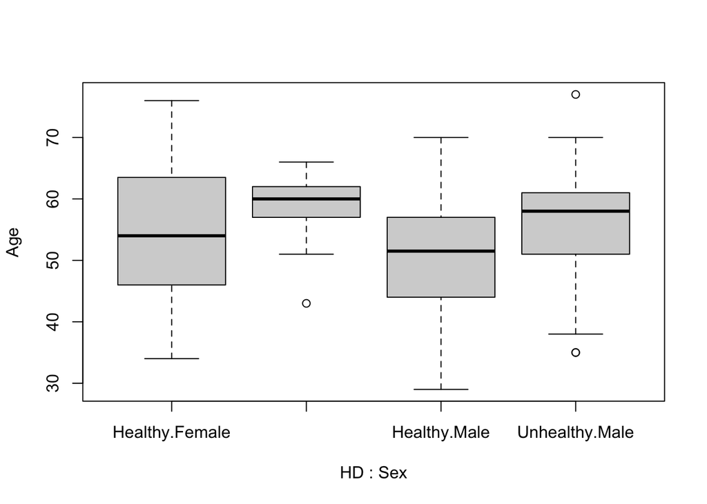

```r
# two-way anova
boxplot(Age~HD+Sex, data = my_data)
```

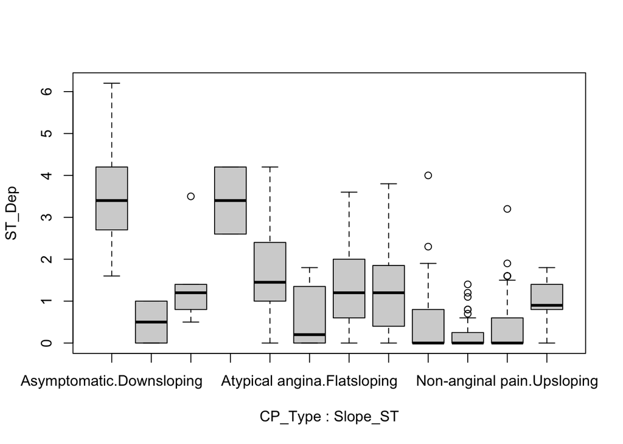

```r
boxplot(ST_Dep~CP_Type+Slope_ST, data = my_data)
```

```r
set.seed(12)
TWO_ANOVA1 <- aov(Age~HD*Sex, data = my_data)
TWO_ANOVA1
```

```
## Call:
##    aov(formula = Age ~ HD * Sex, data = my_data)
##
## Terms:
##                        HD       Sex    HD:Sex Residuals
## Sum of Squares   1286.128   669.240     8.026 22206.553
## Deg. of Freedom         1         1         1       292
##
## Residual standard error: 8.720656
## Estimated effects may be unbalanced
```

```r
summary(TWO_ANOVA1)
```

```
##              Df Sum Sq Mean Sq F value  Pr(>F)
## HD            1   1286  1286.1  16.912 5.1e-05 ***
## Sex           1    669   669.2   8.800 0.00326 **
## HD:Sex        1      8     8.0   0.106 0.74552
## Residuals   292  22207    76.0
## ---
## Signif. codes:  0 '***' 0.001 '**' 0.01 '*' 0.05 '.' 0.1 ' ' 1
```

```r
set.seed(13)
TWO_ANOVA2 <- aov(ST_Dep~CP_Type*Slope_ST, data = my_data)
TWO_ANOVA2
```

```
## Call:
##    aov(formula = ST_Dep ~ CP_Type * Slope_ST, data = my_data)
##
## Terms:
##                   CP_Type  Slope_ST CP_Type:Slope_ST Residuals
## Sum of Squares   48.25395 104.13174         23.68134 224.89243
## Deg. of Freedom         3         2                6       284
##
## Residual standard error: 0.8898734
## Estimated effects may be unbalanced
```

```r
summary(TWO_ANOVA2)
```

```
##                   Df Sum Sq Mean Sq F value   Pr(>F)
## CP_Type            3  48.25   16.08  20.312 5.92e-12 ***
## Slope_ST           2 104.13   52.07  65.750  < 2e-16 ***
## CP_Type:Slope_ST   6  23.68    3.95   4.984 7.14e-05 ***
## Residuals        284 224.89    0.79
## ---
## Signif. codes:  0 '***' 0.001 '**' 0.01 '*' 0.05 '.' 0.1 ' ' 1
```

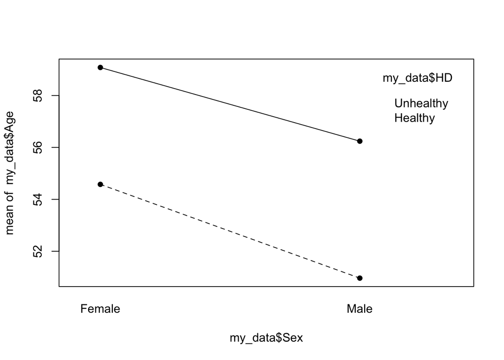

```r
# Chest pain type as prediction for heart disease
interaction.plot(x.factor=my_data$Sex, trace.factor = my_data$HD,my_data$Age, type="o",pch=16)
```

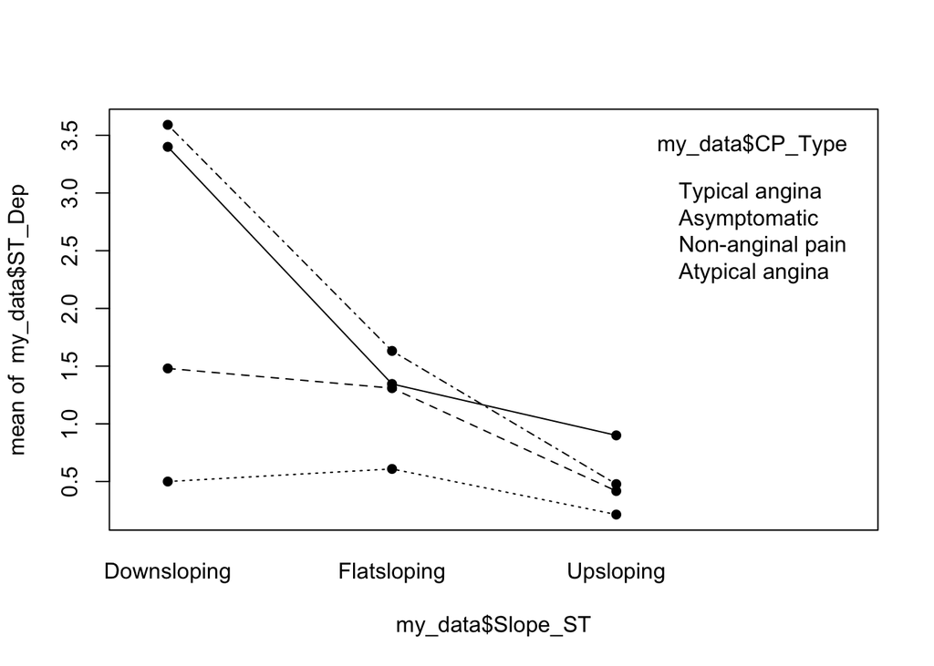

```r
# Slope of heart rate as prediction
interaction.plot(x.factor=my_data$Slope_ST,trace.factor = my_data$CP_Type,my_data$ST_Dep, type="o",pch=16)
```

## Linear Regression | Finding trends and correlation in data

```r
set.seed(14)
linear_model1 <- lm(data = my_data, Cholesterol~Age)
summary(linear_model1)
```

```
##
## Call:
## lm(formula = Cholesterol ~ Age, data = my_data)
##
## Residuals:
##      Min       1Q   Median       3Q      Max
## -124.315  -33.136   -5.525   28.093  301.957
##
## Coefficients:
##             Estimate Std. Error t value Pr(>|t|)
## (Intercept) 183.4632    18.1525   10.11  < 2e-16 ***
## Age           1.1728     0.3285    3.57 0.000417 ***
## ---
## Signif. codes:  0 '***' 0.001 '**' 0.01 '*' 0.05 '.' 0.1 ' ' 1
##
## Residual standard error: 51.07 on 294 degrees of freedom
## Multiple R-squared:  0.04155,    Adjusted R-squared:  0.03829
## F-statistic: 12.75 on 1 and 294 DF,  p-value: 0.0004165
```

```r
cor.test(my_data$Age, my_data$Cholesterol)
```

```
##
##  Pearson's product-moment correlation
##
## data:  my_data$Age and my_data$Cholesterol
## t = 3.5702, df = 294, p-value = 0.0004165
## alternative hypothesis: true correlation is not equal to 0
## 95 percent confidence interval:
##  0.09197918 0.31063179
## sample estimates:
##       cor
## 0.2038462
```

## Report: There was a significant relationship between age and cholesterol level of patients(linear regression, r^2=0.04155, F_1,294=12.75, p=0.0004165). The correlations between these two variables was positive(r=0.2038462)

```r
# Create linear model prediction for the confidence interval band
prediction <- predict.lm(linear_model1, data=my_data, interval = 'confidence',level=0.98)
prediction <- data.frame(prediction)
prediction$Age <- my_data$Age
prediction
```

[output not shown]

[output cut: 282 more lines]

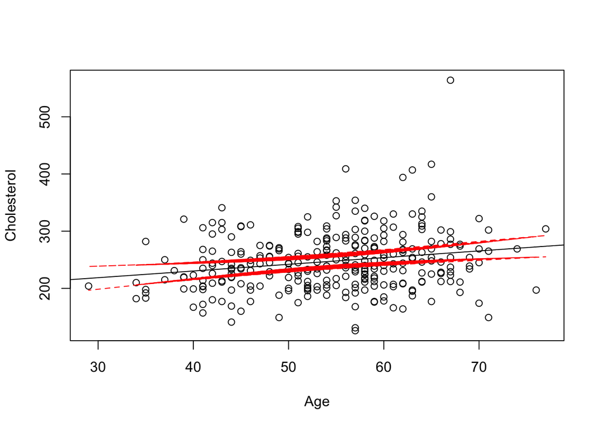

```r
plot(Cholesterol~Age, data = my_data)
abline(lm(Cholesterol~Age, data = my_data))
lines(prediction$Age, prediction$lwr, col="red",lty=2)
lines(prediction$Age, prediction$upr, col="red",lty=2)
```

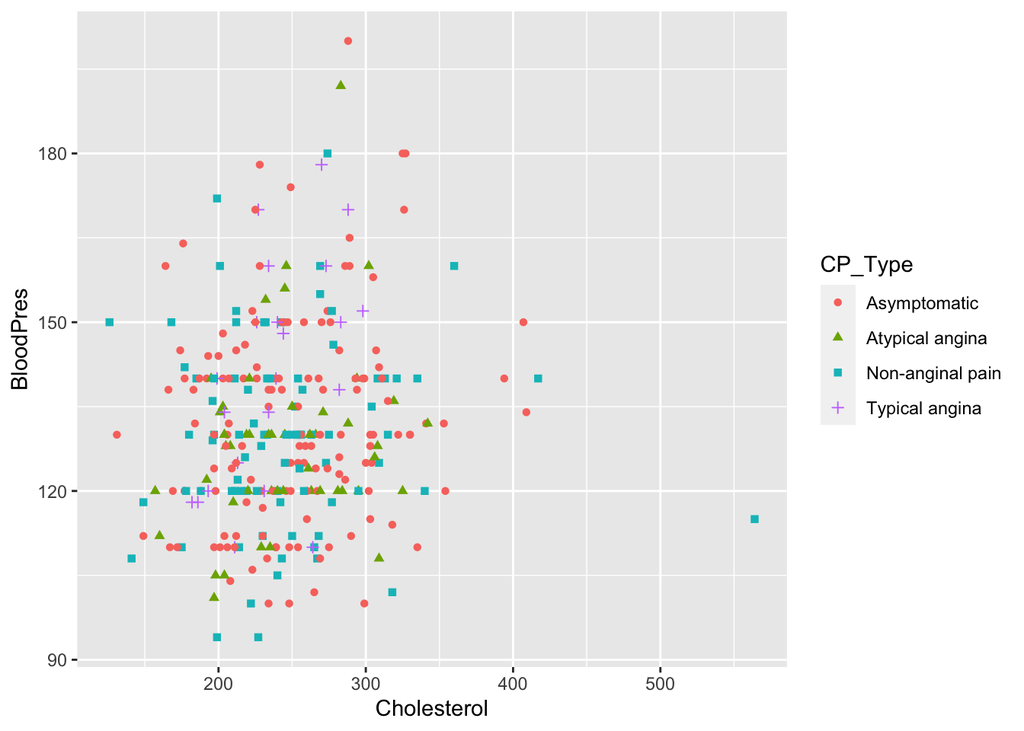

```r
ggplot(data = my_data)+geom_point(mapping = aes(x=Cholesterol, y=BloodPres, color=CP_Type, shape=CP_Type))
```

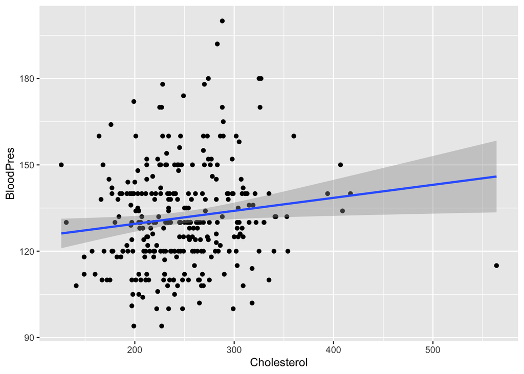

```r
my_data %>% ggplot(aes(x=Cholesterol, y=BloodPres))+geom_point()+
  stat_smooth(method = "lm")
```

```r
# Linear Regression Model
linear_model2 <- lm(data = my_data, BloodPres~Cholesterol)
summary(linear_model2)
```

```
##
## Call:
## lm(formula = BloodPres ~ Cholesterol, data = my_data)
##
## Residuals:
##     Min      1Q  Median      3Q     Max
## -36.727 -11.334  -1.992  10.004  66.517
##
## Coefficients:
##              Estimate Std. Error t value Pr(>|t|)
## (Intercept) 120.47000    4.98815   24.15   <2e-16 ***
## Cholesterol   0.04518    0.01973    2.29   0.0227 *
## ---
## Signif. codes:  0 '***' 0.001 '**' 0.01 '*' 0.05 '.' 0.1 ' ' 1
##
## Residual standard error: 17.65 on 294 degrees of freedom
## Multiple R-squared:  0.01752,    Adjusted R-squared:  0.01418
## F-statistic: 5.244 on 1 and 294 DF,  p-value: 0.02273
```

```r
# run correlation
cor.test(my_data$BloodPres, my_data$Cholesterol)
```

```
##
##  Pearson's product-moment correlation
##
## data:  my_data$BloodPres and my_data$Cholesterol
## t = 2.29, df = 294, p-value = 0.02273
## alternative hypothesis: true correlation is not equal to 0
## 95 percent confidence interval:
##  0.0186566 0.2427210
## sample estimates:
##       cor
## 0.1323796
```

## Report: There was a significant relationship between cholesterol level and blood pressure(linear regression, r^2=0.01752, F_1,294=5.244, p=0.02273). The correlation between these two varibales was positive(r=0.1323796)

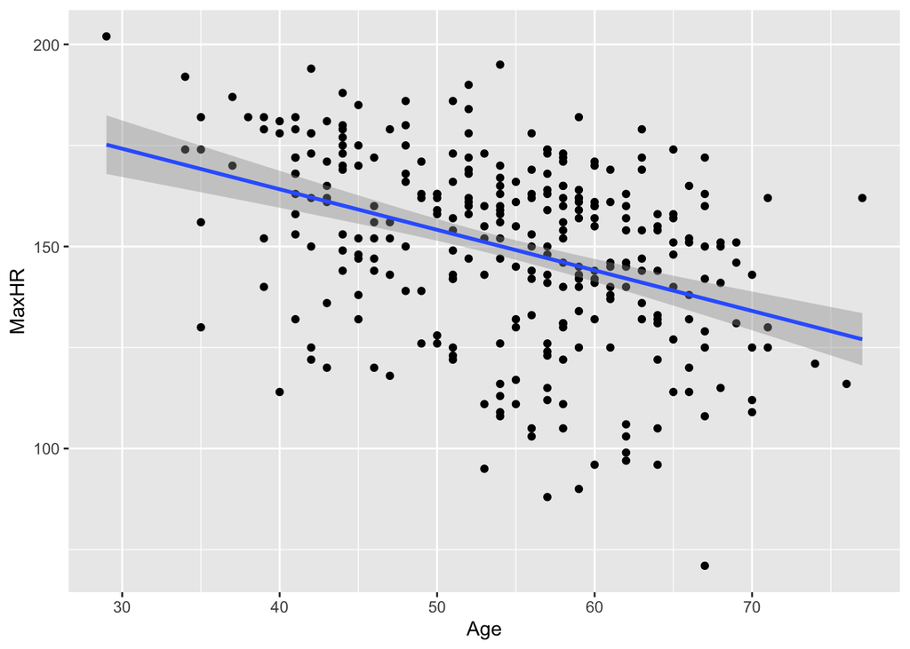

```r
my_data %>% ggplot(aes(x=Age, y=MaxHR))+geom_point()+
  stat_smooth(method = "lm")
```

```r
# Linear model for maximum heart rate and cholesterol
linear_model3 <- lm(data = my_data, MaxHR~Age)
summary(linear_model3)
```

```
##
## Call:
## lm(formula = MaxHR ~ Age, data = my_data)
##
## Residuals:
##    Min     1Q Median     3Q    Max
## -66.07 -12.07   3.88  15.85  44.89
##
## Coefficients:
##             Estimate Std. Error t value Pr(>|t|)
## (Intercept)  204.294      7.516  27.182  < 2e-16 ***
## Age           -1.003      0.136  -7.377 1.66e-12 ***
## ---
## Signif. codes:  0 '***' 0.001 '**' 0.01 '*' 0.05 '.' 0.1 ' ' 1
##
## Residual standard error: 21.15 on 294 degrees of freedom
## Multiple R-squared:  0.1562, Adjusted R-squared:  0.1533
## F-statistic: 54.42 on 1 and 294 DF,  p-value: 1.664e-12
```

```r
# run correlation test
cor.test(my_data$MaxHR, my_data$Age)
```

```
##
##  Pearson's product-moment correlation
##
## data:  my_data$MaxHR and my_data$Age
## t = -7.3769, df = 294, p-value = 1.664e-12
## alternative hypothesis: true correlation is not equal to 0
## 95 percent confidence interval:
##  -0.4872552 -0.2944666
## sample estimates:
##        cor
## -0.3952039
```

## Report: There was a statistically significant relationship age and maximum heart rate(linear regression, r^2=0.1562, F_1,294=54.42, p=1.664e-12). The correlation between these two variables was negative(r=-0.3952039)

# Machine Learning Model

```r
library(caret)
library(randomForest)
library(xgboost)
# data partition/ split data into training and testing
set.seed(123)
data_index <- createDataPartition(my_data$HD, p = .8, list = FALSE)
data_train <-my_data[data_index,]
data_test <- my_data[-data_index,]
```

## Random Forest machine learning model

```r
rf_model <- train(HD ~.,
                    data= data_test,
                    method='rf',
                    metric='Accuracy',
                    trControl=trainControl(method = 'cv', number = 10))
```

```r
rf_model
```

```
## Random Forest
##
## 58 samples
## 13 predictors
##  2 classes: 'Healthy', 'Unhealthy'
##
## No pre-processing
## Resampling: Cross-Validated (10 fold)
## Summary of sample sizes: 52, 52, 52, 52, 52, 52, ...
## Resampling results across tuning parameters:
##
##   mtry  Accuracy   Kappa
##    2    0.7966667  0.5865385
##   11    0.7466667  0.4865385
##   20    0.7833333  0.5583333
##
## Accuracy was used to select the optimal model using the largest value.
## The final value used for the model was mtry = 2.
```

```r
rf_preds <- predict(rf_model, data_test)
table(rf_preds)
```

```
## rf_preds
##   Healthy Unhealthy
##        31        27
```

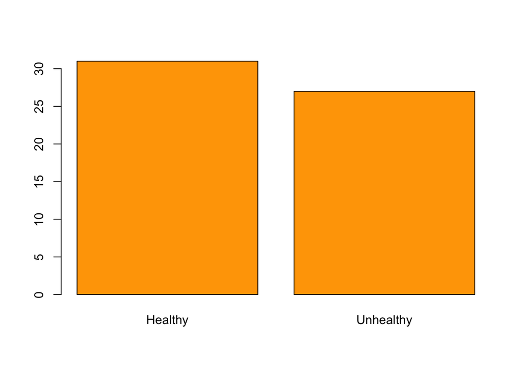

```r
plot(rf_preds, col='orange')
```

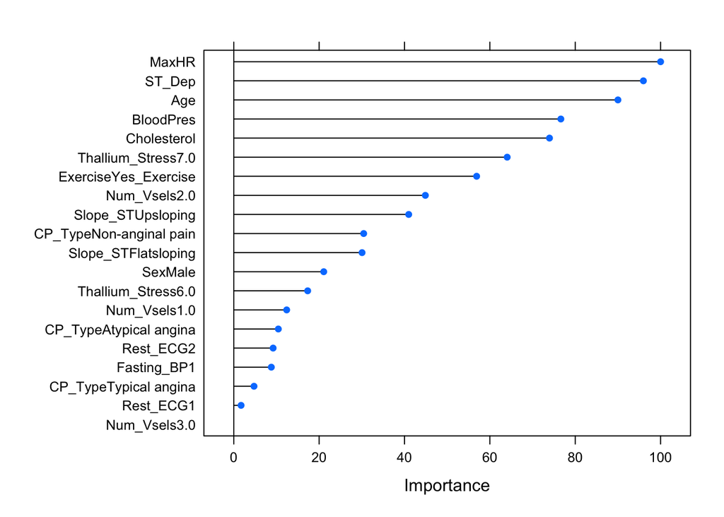

```r
plot(varImp(rf_model, scale = TRUE))
```

## Maximum heart rate is the best indicator for predicting heart condition of patients in this dataset as it shown in this visualization.

```r
confusionMatrix(rf_preds, as.factor(data_test$HD))
```

```
## Confusion Matrix and Statistics
##
##            Reference
## Prediction  Healthy Unhealthy
##   Healthy        31         0
##   Unhealthy       0        27
##
##                Accuracy : 1
##                  95% CI : (0.9384, 1)
##     No Information Rate : 0.5345
##     P-Value [Acc > NIR] : < 2.2e-16
##
##                   Kappa : 1
##
##  Mcnemar's Test P-Value : NA
##
##             Sensitivity : 1.0000
##             Specificity : 1.0000
##          Pos Pred Value : 1.0000
##          Neg Pred Value : 1.0000
##              Prevalence : 0.5345
##          Detection Rate : 0.5345
##    Detection Prevalence : 0.5345
##       Balanced Accuracy : 1.0000
##
##        'Positive' Class : Healthy
##
```